# R Notebook

*3.2. Interpolation à partir de l’histogramme*

```r
plot(z, sapply(z,funHisto), type="l",
     ylim=range(c(y,interpolLagrange(3, a_test, b_test, n_eval_test, 'equi', funHisto))),col = 'black')
grid()
```

```r
title(main = paste("Lagrange interpolation with 4 to 11 chebyshev nodes from histogram"))
lines(z, interpolLagrange(3, a_test, b_test, n_eval_test, 'cheby', funHisto), col = "green")
```

```r
lines(z, interpolLagrange(4, a_test, b_test, n_eval_test, 'cheby', funHisto), col = "yellow")
lines(z, interpolLagrange(6, a_test, b_test, n_eval_test, 'cheby', funHisto), col = "purple")
```

```r
lines(z, interpolLagrange(8, a_test, b_test, n_eval_test, 'cheby', funHisto), col = "blue")
lines(z, interpolLagrange(10, a_test, b_test, n_eval_test, 'cheby', funHisto), col = "red")
```

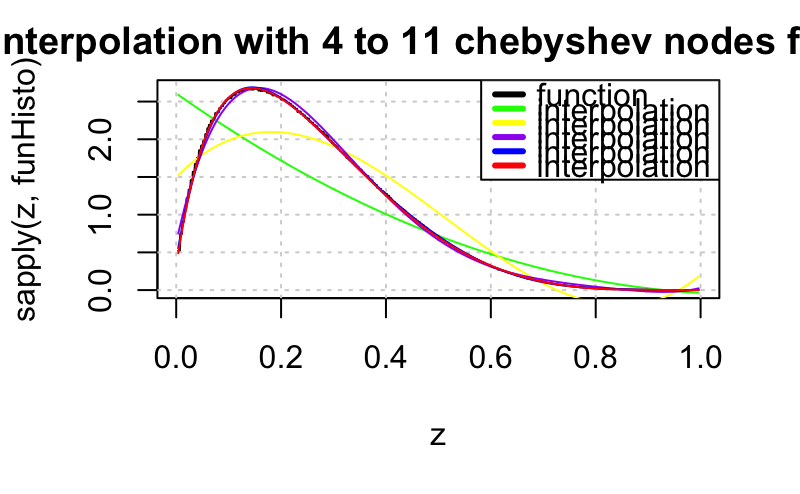

```r
legend('topright',
       legend=c('function','interpolation of degree 3',
        'interpolation of degree 4', 'interpolation of degree 6',
       'interpolation of degree 8', 'interpolation of degree 10'),
       col = c('black','green', 'yellow', 'purple', 'blue', 'red'), lwd=3)
```

```r
plot(z, sapply(z,densite), type="n",
     ylim=range(c(y,interpolLagrange(3, a_test, b_test, n_eval_test, 'equi', funHisto))),
     col = 'black')
grid()
```

```r
title(main = paste("Lagrange interpolation with 21 to 41 chebyshev nodes from histogram"))
lines(z, interpolLagrange(20, a_test, b_test, n_eval_test, 'cheby', funHisto), col = "green")
```

```r
lines(z, interpolLagrange(30, a_test, b_test, n_eval_test, 'cheby', funHisto), col = "yellow")
lines(z, interpolLagrange(40, a_test, b_test, n_eval_test, 'cheby', funHisto), col = "purple")
```

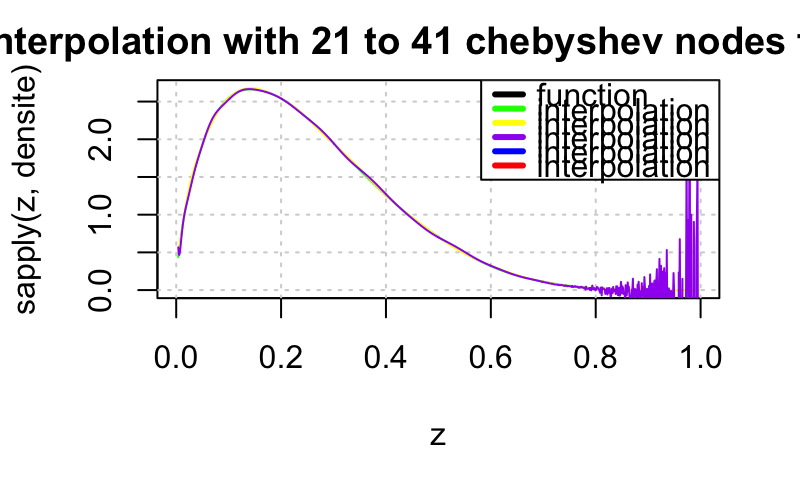

```r
#lines(z, interpolLagrange(50, a_test, b_test, n_eval_test, 'cheby', funHisto), col = "blue")
#lines(z, interpolLagrange(58, a_test, b_test, n_eval_test, 'cheby', funHisto), col = "red")
legend('topright', legend=c('function','interpolation of degree 20',
                            'interpolation of degree 30', 'interpolation of degree 40',
                            'interpolation of degree 50', 'interpolation of degree 58'),
                            col = c('black','green', 'yellow', 'purple', 'blue', 'red', 'gray'), lwd=3)
```

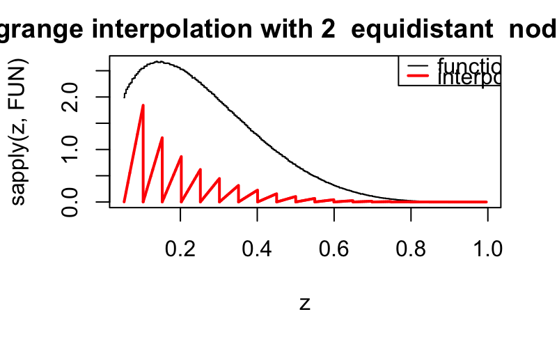

```r
piecewiseInterpol(1, 20, a_test, b_test, 1000, 'equi', funHisto, TRUE)
```

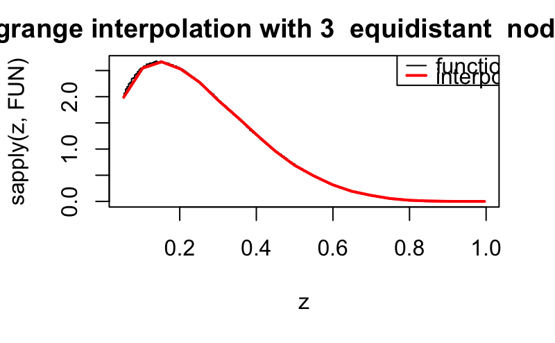

```r
piecewiseInterpol(2, 20, a_test, b_test, 1000, 'equi', funHisto, TRUE)
```

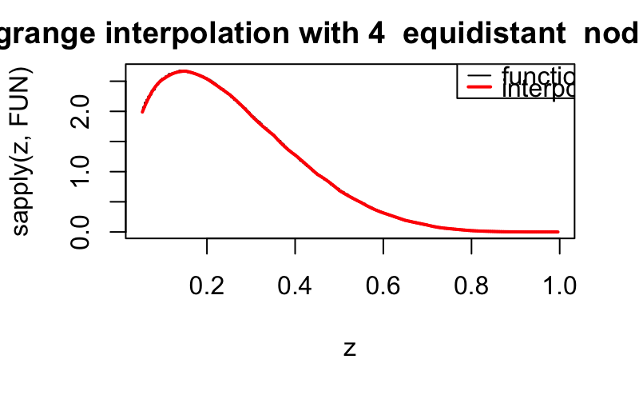

```r
piecewiseInterpol(3, 20, a_test, b_test, 1000, 'equi', funHisto, TRUE)
```

#### 4. Méthode de quadrature

*4.1. Estimation de* $p_{0.1}$ *à partir de la densité* $\phi{1.7,5.1}$

4.1.1.

```r
trapezeInt =function(FUN,a,b,M){
    ##' TRAPEZOIDAL INTEGRATION RULE (COMPOSITE)
    ##' @param FUN : the function to be integrated
    ##' @param a, b : interval end points
    ##' @param M : number of intervals (each of size (b-a)/M)
    ##' @return: the value of the composite trapezoidal quadrature.
    x = seq(a,b, length.out= M+1)
    y = sapply(x, FUN)
    h = (b-a)/M
    q = h*sum(y)-(h/2)*(y[1]+y[M+1])
    return(q)
}
refineTrapeze=function(FUN,a,b,M,q){
    ##' refinement of the subdivision step: incremental method
    ##' @param FUN : the function to be integrated
    ##' @param a, b : interval end points
    ##' @param M : initial number of intervals (each of size (b-a)/M)
    ##'  having been used to compute q
    ##' @param  q : the value of the trapezoidal  quadrature method
    ##'  of stepsize (b-a)/M
    ##' @return : the value of the quadrature for a stepsize h' = h/2
    h = (b-a)/M
    x = seq(a+h/2,b-h/2, length.out = M)
    ##  x : a vector of size M :
    ##     the additional abscissas where 'fun' must be evaluated.
    y = sapply(x, FUN)
    Q = q/2 + (h/2)*sum(y)
    return(Q)
}
simpsonInt = function(FUN,a,b,M){
    ##' Simpson integration via trapeze rule
    ##' uses the fact that
    ##' simpson(h) = 4/3(trapeze(h/2) - 1/4 trapeze(h))
    h = (b-a)/M;
    qtrapeze = trapezeInt(FUN,a,b,M)
    qrefined = refineTrapeze(FUN,a,b,M,qtrapeze)
    q =  (4/3)*(qrefined) - ((1/3)*qtrapeze)
    return(q)
}
IntSimpM = simpsonInt(densite,0.1,0.9, 2)
for (M in (3:25)){
  IntSimpM = c(IntSimpM, simpsonInt(densite,0.1,0.9, M))
}
M =  seq(2, 25)
plot(M, IntSimpM, type = 'o', ylim = range(c(0.82,simpsonInt(densite,0.1,0.9, 14))), ylab = "Valeur de l'intégrale")
title(main = "Estimation de l'intégrale par une méthode de simpson composite")
```

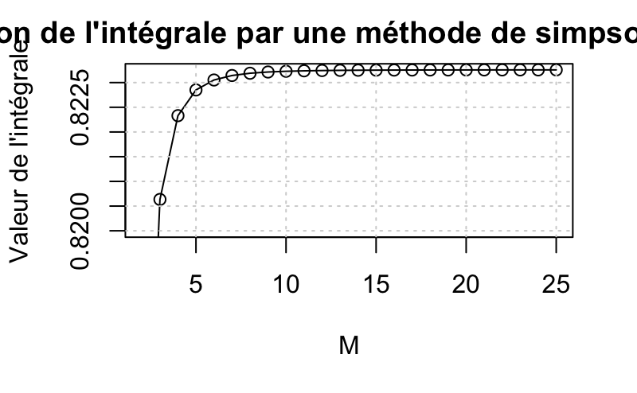

```r
grid()
```

Ainsi, on peut en déduire en première approximation que $p_{0.1} \simeq 0.823$.

```r
q = c(0.1,0.9)
p = pbeta(q, 1.7, 5.1)
IntExact = (p[2]-p[1])
Precision = (abs(0.823-IntExact)/IntExact) *100
print(paste('En première approximation, nous avons une erreur de', floor(100*Precision)/100,' %'))
```

```
[1] "En première approximation, nous avons une erreur de 0.03  %"
```

4.1.2. (a) :

L’odre de grandeur théorique de l’erreur de la méthode de Simpson est de : $EI_{M}^{(0.1,0.9)}(p) \simeq p^{(3)}.\theta_{2,M}.(b-a).h^{3}$

avec $\theta_{2,M} \in [a,b[$ et $a = 0.1$ et $b=0.9$.

d’où $\theta_{2,M} \simeq 0.5$ et :

```r
p0.1.table = pbeta(q, 1.7, 5.1)
p0.1.table = (p0.1.table[2]-p0.1.table[1])
logDiff = log(abs(p0.1.table-IntSimpM))
logM = log(M)
pente = abs((logDiff[1]-logDiff[20])/(logM[1]-logM[20]))
plot(logM, logDiff, type='o')
title(main = "Logarithme de la valeur absolue de l'erreur")
```

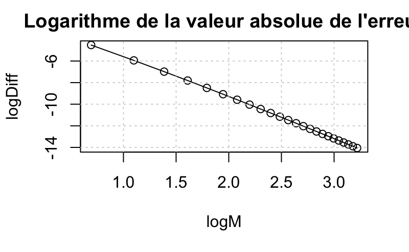

```r
grid()
```

```r
print(paste("La courbe semble être une droite de pente", floor(100*pente)/100))
```

```
[1] "La courbe semble être une droite de pente 3.75"
```

On trouve bien une pente de d’environ -4, ce qui est en accord avec le cours ! En effet, l’erreur de la méthode de simpson est approximée à $\simeq K.h^{4}$ avec K une constante. En echelle logarithmique, on obtient bien une pente de -4 en fonction de log(M).

```r
 evalErrSimpson=function(FUN,a,b,M){
  ## Computes an approximation E of the error
  ## for the composite Simpson rule of step h=(b-a)/(2M).
  ##This requires computing I_M and I_{2M}.
  ##The value  q = I_{2M} is also returned.
  qth = trapezeInt(FUN,a,b,M)   ## M +1 evaluations
  qth2 = refineTrapeze ( FUN,a,b,M,qth )  ## M evaluations
  qth4 = refineTrapeze ( FUN,a,b,2*M,qth2 )   ## 2M evaluations
  simps_h =   4/3*(qth2 - 1/4* qth )
  simps_h2 =  4/3*(qth4 - 1/4* qth2 )
  q = simps_h2
  E = (simps_h - q)/15
    return(E)
 }
M = seq(14, 80)
ErrAbs =  c()
for(k in (14:80)){
  ErrAbs = c(ErrAbs, evalErrSimpson(densite, 0.1, 0.9, k))
}
logErrAbs = log(abs(ErrAbs))
logM = log(M)
penteAbs = abs((logErrAbs[20]-logErrAbs[50])/(logM[20]-logM[50]))
plot(logM, logErrAbs, ylim = range(c(-30, -5)))
grid()
```

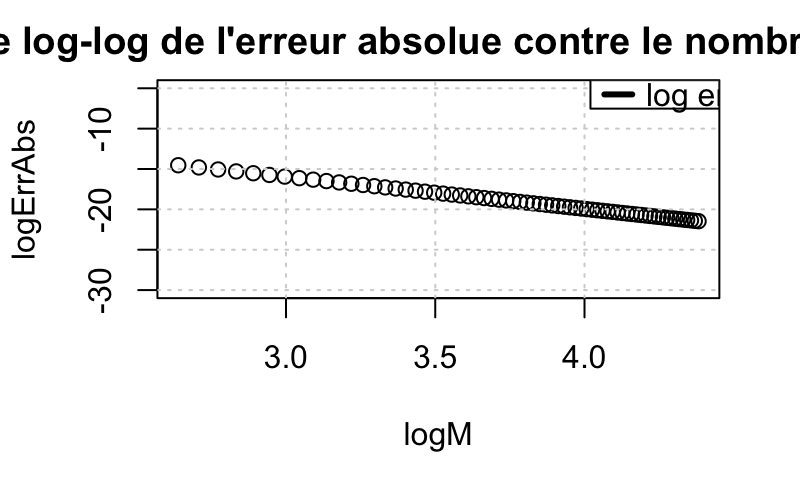

```r
title (main = "Graphe log-log de l'erreur absolue contre le nombre de pas M")
legend('topright', legend = c("log erreur"), col = c('black'), lwd = 3)
```

```r
print(paste("le modèle est d'une pente d'environ -", floor(100*penteAbs)/100))
```

```
[1] "le modèle est d'une pente d'environ - 3.99"
```

On trouve approximativement la même pente, ce qui est cohérent avec la 2.(b). Quoique beaucoup plus proche de la valeur théorique, de -4.

4.1.3.

```r
quadrature = function(FUN,a,b,M){
   qth = trapezeInt(FUN,a,b,M)   ## M +1 evaluations
  qth2 = refineTrapeze ( FUN,a,b,M,qth )  ## M evaluations
  qth4 = refineTrapeze ( FUN,a,b,2*M,qth2 )   ## 2M evaluations
  simps_h =   4/3*(qth2 - 1/4* qth )
  simps_h2 =  4/3*(qth4 - 1/4* qth2 )
  return (simps_h2)
}
choixDuM = function(FUN, a, b, tolerance){
  M = 10 ; erreur = 1 ; Mvecteur = 0 ; Qvecteur = 0 ; Evecteur = 0 ;
  while ( 2*erreur > tolerance) {
    a = evalErrSimpson(FUN,a,b,2*M)
    quadrature = quadrature(FUN, a, b, 2*M)
    Mvecteur = c(Mvecteur, M) ; Qvecteur = c(Qvecteur, quadrature) ;   Evecteur = c(Evecteur, erreur)
    erreur = a
    M = 2 * M
  }
  return (M)
}
approxfinale = simpsonInt(densite, 0.1, 0.9, choixDuM(densite, 0.1, 0.9,10^(-8)))
print(paste("une approximation de p0.1 à", 10^-8, "près vaut :", floor(100000000*approxfinale)/100000000))
```

```
[1] "une approximation de p0.1 à 1e-08 près vaut : 0.82325588"
```

#### 4.2.

4.2.1.

```r
densite_bruitee = function(x) {
  return (funHisto(x))
}
```

4.2.2.

La théorie nous dit que $\Delta_{M} \rightarrow 0~quand~ M\rightarrow \infty .$

4.2.3.

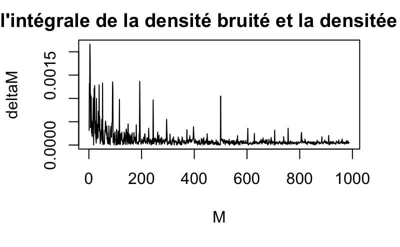

```r
M = seq(13:1000)
deltaM = abs(simpsonInt(densite_bruitee, 0.1, 0.9, 13) - simpsonInt(densite, 0.1, 0.9, 13))
for (k in (14 : 1000)) {
  deltaM = c(deltaM, abs(simpsonInt(densite_bruitee, 0.1, 0.9, k) - simpsonInt(densite, 0.1, 0.9, k)))
}
plot(M, deltaM, type = 'l')
title(main = "Ecart absolu entre l'intégrale de la densité bruité et la densitée réelle en fonction de M")
```

Non seulement la théorie est vérifiée expérimentalement, mais on s’aperçoit que la convergence est rapide bien que non uniforme. En effet, $\Delta_{M}$ est toujours inférieur à 0.002, et diminue rapidement par la suite.

### 5 Extrapolation de Richardson et méthode de Romberg

##### Estimation de p0.1

5.1.

```r
romberg =function(FUN,n,a,b,M){## methode de Romberg avec n etapes
    ## appliquee sur la fonction FUN sur l'intervalle (a,b), avec un
    ## pas initial h = (b-a)/M
    h= (b-a)/M
    A = rep(0, n+1)
    A[1] = trapezeInt(FUN,a,b,M);
    Mc = M
    ## initialisation des differences divisees
    for( i in 2:(n+1)){
        A[i] = refineTrapeze( FUN,a,b, Mc, q= A[i-1])
        Mc = 2*Mc
    }
    delta = 1/4;
    for (j in 2:(n+1)){
           A[j : (n+1) ] = (A[j:(n+1)] - (delta^(j-1))*A[(j-1):n]) / (1 - delta^(j-1))
    }
    return(A)
}
n = 12 ; M = 3
estRomberg = romberg(densite, n, 0.1, 0.9, M)
plot(estRomberg, type = 'o')
grid()
```

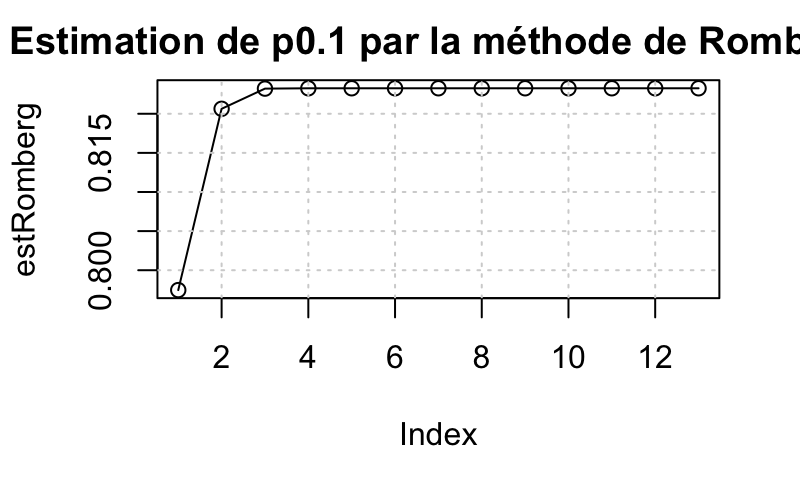

```r
title(main = 'Estimation de p0.1 par la méthode de Romberg')
```

5.2.

```r
plot(0:12, log(abs(p0.1.table-estRomberg)) )
grid()
```

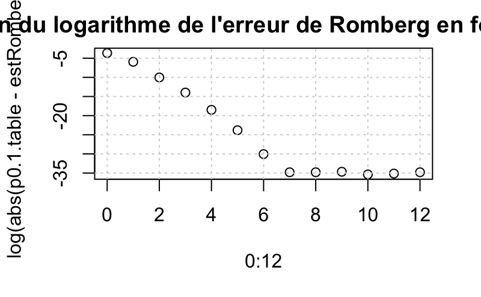

```r
title(main = "Evolution du logarithme de l'erreur de Romberg en fonction de M")
```

```r
I = c()
for (k in (0:20)){
  I = c(I, simpsonInt(densite, 0.1, 0.9, 3*2^k))
}
plot(log(abs(p0.1.table-I)))
grid()
```

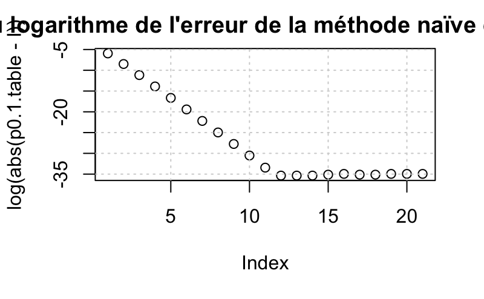

```r
title(main = "Evolution du logarithme de l'erreur de la méthode naïve en fonction de M")
```

Le pallier correspond à la saturation de la méthode : l’erreur diminue plus vite avec Romberg (lorsque n augmente), mais termine par ce stabiliser ce qui produit un palier.

Pour la méthode naïve, on voit que l’erreur se stabilise aussi autour de la même valeur finale mais converge plus lentement.

En effet, la valeur finale de l’erreur logarithmique ($\simeq -35$) est atteinte pour n = 7 pour la méthode de Romberg, mais n = 11 pour la méthode naïve.

Remarque : la méthode de Romberg est tout de même beaucoup plus rapide, car n = 11 correspont à $m = 2^{11}*M$ ce qui est très long !